# BBC_RNN

## BBC - auto categorize the news into various categories which will help in recommending the right news articles to it users at a later stage.

#### Importing Libraries

```python
import pandas as pd
import numpy as np
from IPython.display import Image
from tqdm import tqdm
from sklearn.preprocessing import LabelEncoder
from sklearn.metrics import confusion_matrix, accuracy_score
import re
import matplotlib.pyplot as plt
```

### Reading the dataset

```python
!gdown 1POmzYEQZgZVqJO3F_cyNcd4QmoNE_mCv
```

```
Downloading...
From: https://drive.google.com/uc?id=1POmzYEQZgZVqJO3F_cyNcd4QmoNE_mCv
To: C:\Users\Home\bbc-news-data.csv

 52%|#####1    | 2.62M/5.08M [00:00<00:00, 6.43MB/s]
 72%|#######2  | 3.67M/5.08M [00:00<00:00, 5.96MB/s]
 93%|#########2| 4.72M/5.08M [00:00<00:00, 6.28MB/s]
```

```python
df = pd.read_csv("bbc-news-data.csv", sep="\t")
df
```

|  | category | filename | title | content |
| --- | --- | --- | --- | --- |
| 0 | business | 001.txt | Ad sales boost Time Warner profit | Quarterly profits at US media giant TimeWarne... |
| 1 | business | 002.txt | Dollar gains on Greenspan speech | The dollar has hit its highest level against ... |
| 2 | business | 003.txt | Yukos unit buyer faces loan claim | The owners of embattled Russian oil giant Yuk... |
| 3 | business | 004.txt | High fuel prices hit BA's profits | British Airways has blamed high fuel prices f... |
| 4 | business | 005.txt | Pernod takeover talk lifts Domecq | Shares in UK drinks and food firm Allied Dome... |
| ... | ... | ... | ... | ... |
| 2220 | tech | 397.txt | BT program to beat dialler scams | BT is introducing two initiatives to help bea... |
| 2221 | tech | 398.txt | Spam e-mails tempt net shoppers | Computer users across the world continue to i... |
| 2222 | tech | 399.txt | Be careful how you code | A new European directive could put software w... |
| 2223 | tech | 400.txt | US cyber security chief resigns | The man making sure US computer networks are ... |
| 2224 | tech | 401.txt | Losing yourself in online gaming | Online role playing games are time-consuming,... |

2225 rows × 4 columns

## Dropping the empty sub-title

```python
df = df[((~df.title.isnull()) & (~df.content.isnull()))].reset_index(drop=True)
print(df.shape)

df
```

```
(2225, 4)
```

|  | category | filename | title | content |
| --- | --- | --- | --- | --- |
| 0 | business | 001.txt | Ad sales boost Time Warner profit | Quarterly profits at US media giant TimeWarne... |
| 1 | business | 002.txt | Dollar gains on Greenspan speech | The dollar has hit its highest level against ... |
| 2 | business | 003.txt | Yukos unit buyer faces loan claim | The owners of embattled Russian oil giant Yuk... |
| 3 | business | 004.txt | High fuel prices hit BA's profits | British Airways has blamed high fuel prices f... |
| 4 | business | 005.txt | Pernod takeover talk lifts Domecq | Shares in UK drinks and food firm Allied Dome... |
| ... | ... | ... | ... | ... |
| 2220 | tech | 397.txt | BT program to beat dialler scams | BT is introducing two initiatives to help bea... |
| 2221 | tech | 398.txt | Spam e-mails tempt net shoppers | Computer users across the world continue to i... |
| 2222 | tech | 399.txt | Be careful how you code | A new European directive could put software w... |
| 2223 | tech | 400.txt | US cyber security chief resigns | The man making sure US computer networks are ... |
| 2224 | tech | 401.txt | Losing yourself in online gaming | Online role playing games are time-consuming,... |

2225 rows × 4 columns

## Visualization of category distribution

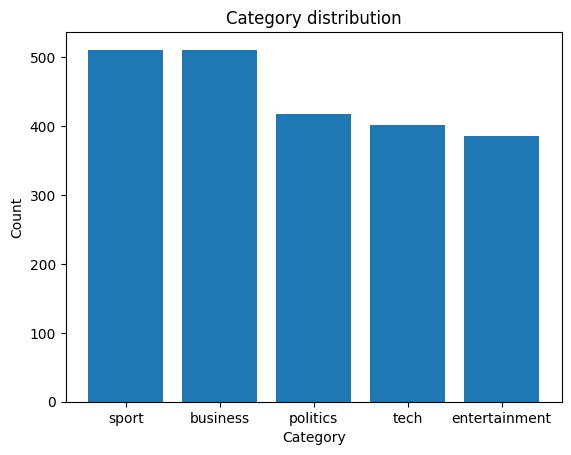

```python
plt.bar(df.category.value_counts().index, df.category.value_counts().values)
plt.title('Category distribution')
plt.xlabel("Category")
plt.ylabel("Count")
```

## sample example of how the data

```python
ind=1807
print(f'Title: {df.title[ind]}')
print(f'Category: {df.category[ind]}')
```

```
Title: Federer joins all-time greats
Category: sport
```

## Importing tensorflow and keras

```python
from tensorflow.keras.preprocessing.sequence import pad_sequences
from tensorflow.keras.layers import Dense, Embedding, Input, InputLayer, RNN,SimpleRNN
from tensorflow.keras.models import Model, Sequential
from tensorflow.keras.callbacks import EarlyStopping
from tensorflow.keras.preprocessing.text import Tokenizer
import tensorflow as tf

import string

import nltk
nltk.download('stopwords')

from nltk.corpus import stopwords
stop_words = stopwords.words('english')

from sklearn.model_selection import train_test_split

import matplotlib.pyplot as plt
import seaborn as sns
```

### Text cleaning

```python
def data_cleaning(text):

    # Lower the words in the sentence
    cleaned = text.lower()

    # Replace the full stop with a full stop and space
    cleaned = cleaned.replace(".", ". ")

    # Remove the stop words
    tokens = [word for word in cleaned.split() if not word in stop_words]

    # Remove the punctuations
    tokens = [tok.translate(str.maketrans(' ', ' ', string.punctuation)) for tok in tokens]

    # Joining the tokens back to form the sentence
    cleaned = " ".join(tokens)

    # Remove any extra spaces
    cleaned = cleaned.strip()

    return cleaned
```

```python
for index, data in tqdm(df.iterrows(), total=df.shape[0]):
    df.loc[index, 'title'] = data_cleaning(data['title'])
```

## Fixing the sequence length

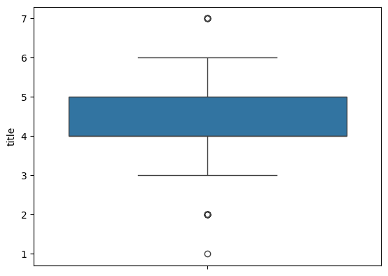

```python
sns.boxplot(df['title'].str.split(" ").str.len())
```

maximum number of words in the title is 7, we can set the sequence length to be the max words in the longest sentence.

```python
max_sentence_len = df['title'].str.split(" ").str.len().max()
total_classes = df.category.nunique()

print(f"Maximum sequence length: {max_sentence_len}")
print(f"Total classes: {total_classes}")
```

```
Maximum sequence length: 7
Total classes: 5
```

## Splitting the data to train and test

```python
np.random.seed(100)
train_X, test_X, train_Y, test_Y = train_test_split(df['title'], #X
                                                    df['category'], #y
                                                    test_size=0.2,
                                                    random_state=100)
train_X = train_X.reset_index(drop=True)
test_X = test_X.reset_index(drop=True)
train_Y = train_Y.reset_index(drop=True)
train_Y = train_Y.reset_index(drop=True)
```

```python
train_X.shape, train_Y.shape, test_X.shape, test_Y.shape
```

```
((1780,), (1780,), (445,), (445,))
```

### One hot Encode the labels

```python
train_Y = pd.get_dummies(train_Y).values
test_Y = pd.get_dummies(test_Y).values
```

```python
validation = test_Y.argmax(axis=1)
```

### Tokenize the input text and pad them

```python
def tokenize_and_pad(inp_text, max_len, tok):

    text_seq = tok.texts_to_sequences(inp_text)
    text_seq = pad_sequences(text_seq, maxlen=max_len, padding='post')

    return text_seq

text_tok = Tokenizer()
text_tok.fit_on_texts(train_X)
train_text_X = tokenize_and_pad(inp_text=train_X, max_len=max_sentence_len, tok=text_tok)
test_text_X = tokenize_and_pad(inp_text=test_X, max_len=max_sentence_len, tok=text_tok)
vocab_size = len(text_tok.word_index)+1

print("Overall text vocab size", vocab_size)
```

```
Overall text vocab size 3339
```

## Latent dimension and embedding dimension

#### Latent dimension: Dimension of the weight matrix U, V, W

#### Embedding dimension: Dimension of the word embeddings at the embedding layer

```python
latent_dim=50
embedding_dim=100
```

## Define the RNN model architecture

#### The embedding layer with 100 dimension

#### A single Vanilla RNN unit with 50 dimensions

#### A final output layer with 5 units(5 classes) with the softmax activation function

```python
seed=56
tf.random.set_seed(seed)
np.random.seed(seed)

model = Sequential()
model.add(Embedding(vocab_size, embedding_dim, trainable=True))
model.add(SimpleRNN(latent_dim, recurrent_dropout=0.2, return_sequences=False, activation='tanh'))
model.add(Dense(total_classes, activation='softmax'))
model.summary()
```

```
Model: "sequential_2"
```

```
┏━━━━━━━━━━━━━━━━━━━━━━━━━━━━━━━━━━━━━━┳━━━━━━━━━━━━━━━━━━━━━━━━━━━━━┳━━━━━━━━━━━━━━━━━┓
┃ Layer (type)                         ┃ Output Shape                ┃         Param # ┃
┡━━━━━━━━━━━━━━━━━━━━━━━━━━━━━━━━━━━━━━╇━━━━━━━━━━━━━━━━━━━━━━━━━━━━━╇━━━━━━━━━━━━━━━━━┩
│ embedding_2 (Embedding)              │ ?                           │     0 (unbuilt) │
├──────────────────────────────────────┼─────────────────────────────┼─────────────────┤
│ simple_rnn (SimpleRNN)               │ ?                           │     0 (unbuilt) │
├──────────────────────────────────────┼─────────────────────────────┼─────────────────┤
│ dense (Dense)                        │ ?                           │     0 (unbuilt) │
└──────────────────────────────────────┴─────────────────────────────┴─────────────────┘
```

```
 Total params: 0 (0.00 B)
```

```
 Trainable params: 0 (0.00 B)
```

```
 Non-trainable params: 0 (0.00 B)
```